# Studi Kasus 2 - Regresi Spasial

**Kemiskinan di Bali dan Nusa Tenggara**

Digunakan data dengan peubah Y adalah persentase penduduk miskin di Bali dan Nusa Tenggara pada tahun 2023

# *Package*

```r
library(sf)
```

```r
library(readxl)
library(ggplot2)
library(spdep)
library(spatialreg)
library(sp)
library(tmap)
library(corrplot)
library(DescTools)
library(nortest)
library(car)
library(spatialreg)
library(lmtest)
library(dplyr)
library(RColorBrewer)
```

# Data

```r
indonesia_map <- st_read("D:/KULIAHH/SEMESTER 5/REGSPAS/INDONESIA/idn_admbnda_adm2_bps_20200401.shp")
data <- read_excel("D:/KULIAHH/SEMESTER 5/REGSPAS/STUDI KASUS 2/Data Studi Kasus 2.xlsx", sheet="Data")
```

```r
wilayah_dipilih <- c("Bali", "Nusa Tenggara Barat", "Nusa Tenggara Timur")
tts_map <- indonesia_map[indonesia_map$ADM1_EN %in% wilayah_dipilih, ]
```

```r
merged_map <- merge(tts_map, data, by.x = c("ADM2_EN"), by.y = c("KABUPATEN/KOTA"), all.x = TRUE)
```

# Ekplorasi Data

## Memeriksa *Missing Value*

```r
data[!complete.cases(data),]
```

```
## # A tibble: 0 × 8
## # ℹ 8 variables: KABUPATEN/KOTA <chr>, PPM <dbl>, TPT <dbl>, AML <dbl>,
## #   SL <dbl>, RLS <dbl>, PKD <dbl>, UHH <dbl>
```

## Ringkasan Statistik Deskripsi

```r
summary(data)
```

```
##  KABUPATEN/KOTA          PPM             TPT              AML
##  Length:41          Min.   : 2.30   Min.   :0.7529   Min.   : 56.66
##  Class :character   1st Qu.: 8.62   1st Qu.:2.4418   1st Qu.: 88.10
##  Mode  :character   Median :13.91   Median :2.7228   Median : 95.49
##                     Mean   :15.50   Mean   :2.9366   Mean   : 91.91
##                     3rd Qu.:22.86   3rd Qu.:3.5419   3rd Qu.: 98.45
##                     Max.   :31.78   Max.   :5.6864   Max.   :100.00
##        SL             RLS              PKD             UHH
##  Min.   :48.22   Min.   : 6.380   Min.   : 5899   Min.   :66.46
##  1st Qu.:77.81   1st Qu.: 7.120   1st Qu.: 7907   1st Qu.:71.28
##  Median :84.92   Median : 7.940   Median : 9404   Median :72.59
##  Mean   :82.35   Mean   : 8.154   Mean   :10171   Mean   :72.49
##  3rd Qu.:90.99   3rd Qu.: 8.650   3rd Qu.:11760   3rd Qu.:73.98
##  Max.   :99.92   Max.   :11.620   Max.   :20128   Max.   :75.73
```

```r
kab_max <- data %>%
  arrange(desc(PPM)) %>%
  slice(1)

print(paste("Kabupaten/kota dengan persentase penduduk miskin tertinggi di Pulau Bali dan Nusa Tenggara adalah", kab_max$`KABUPATEN/KOTA`))
```

```
## [1] "Kabupaten/kota dengan persentase penduduk miskin tertinggi di Pulau Bali dan Nusa Tenggara adalah Sumba Tengah"
```

```r
kab_min <- data %>%
  arrange(PPM) %>%
  slice(1)

print(paste("Kabupaten/kota dengan persentase penduduk miskin terrendah di Pulau Bali dan Nusa Tenggara adalah", kab_min$`KABUPATEN/KOTA`))
```

```
## [1] "Kabupaten/kota dengan persentase penduduk miskin terrendah di Pulau Bali dan Nusa Tenggara adalah Badung"
```

## *Boxplot*

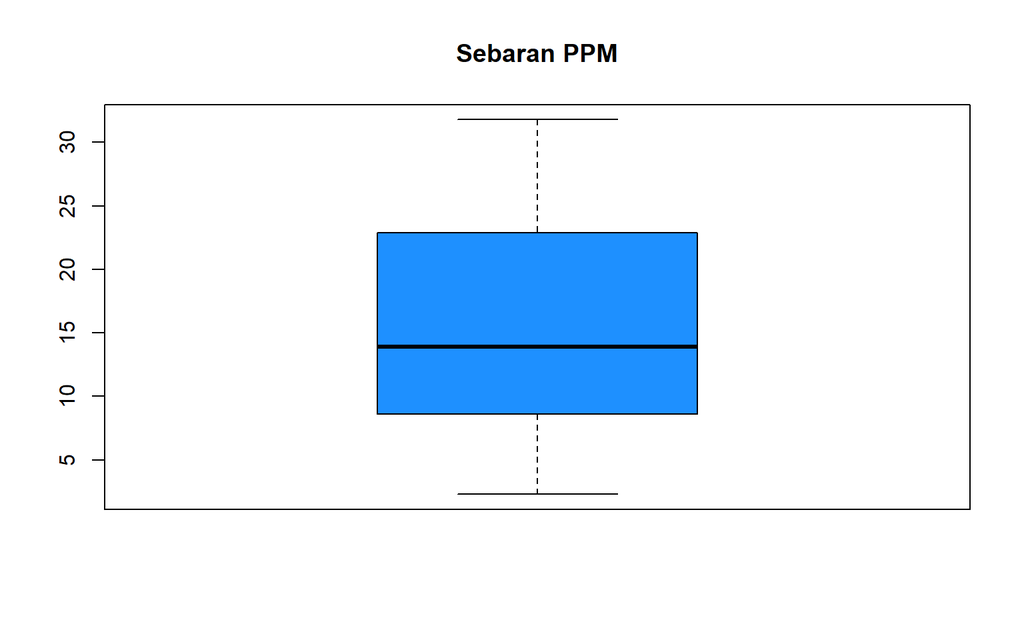

```r
boxplot(data$PPM,main = "Sebaran PPM", col="dodgerblue")
```

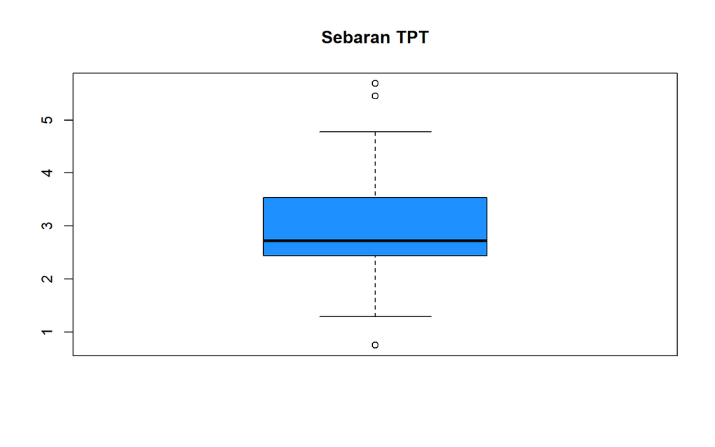

```r
boxplot(data$TPT,main = "Sebaran TPT", col="dodgerblue")
```

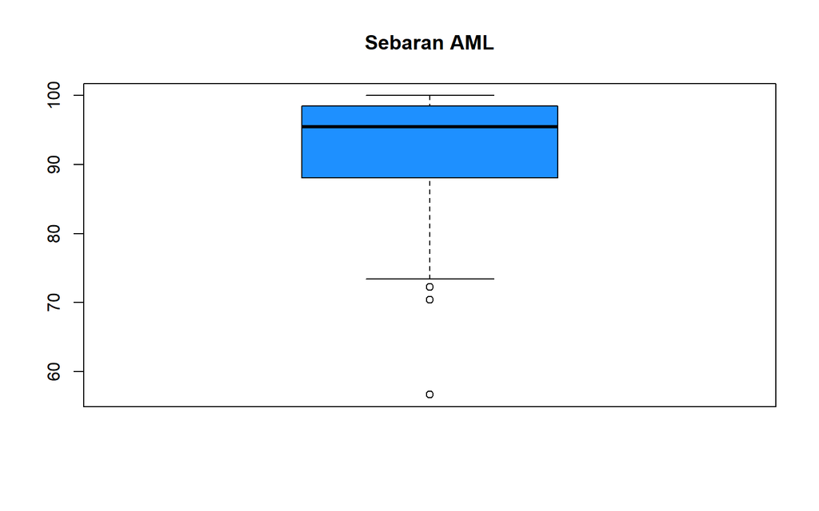

```r
boxplot(data$AML,main = "Sebaran AML", col="dodgerblue")
```

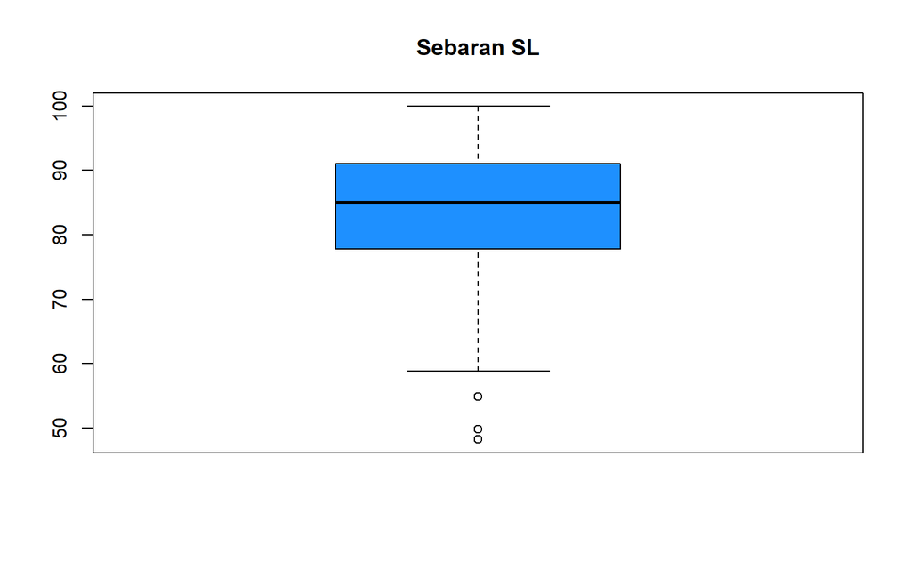

```r
boxplot(data$SL,main = "Sebaran SL", col="dodgerblue")
```

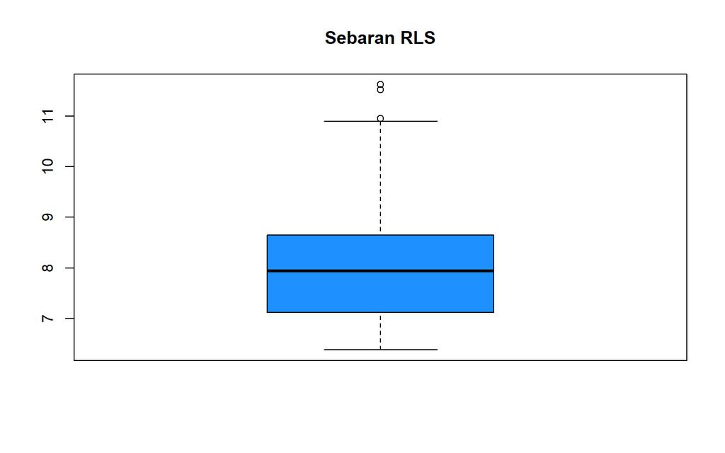

```r
boxplot(data$RLS,main = "Sebaran RLS", col="dodgerblue")
```

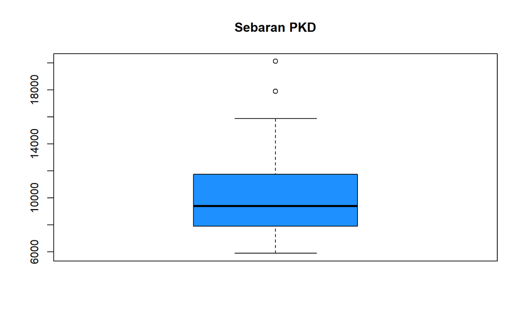

```r
boxplot(data$PKD,main = "Sebaran PKD", col="dodgerblue")
```

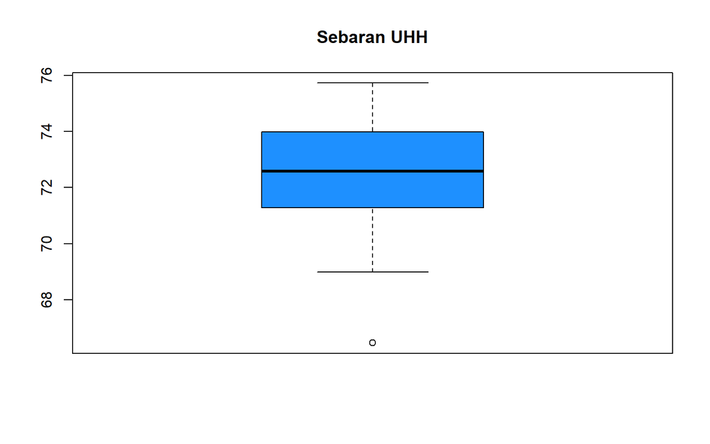

```r
boxplot(data$UHH,main = "Sebaran UHH", col="dodgerblue")
```

## Hubungan antara Peubah Respon dan Peubah Penjelas

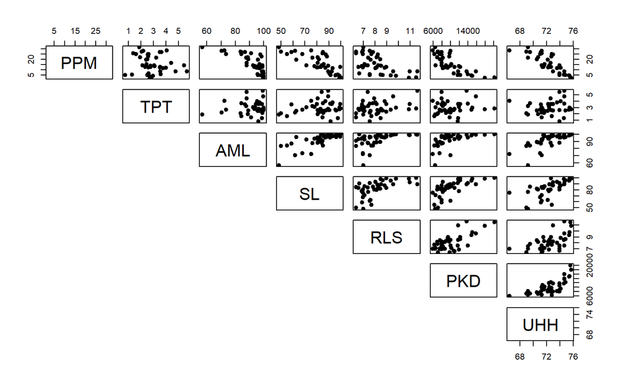

```r
pairs(data[,2:8], pch = 19, lower.panel = NULL)
```

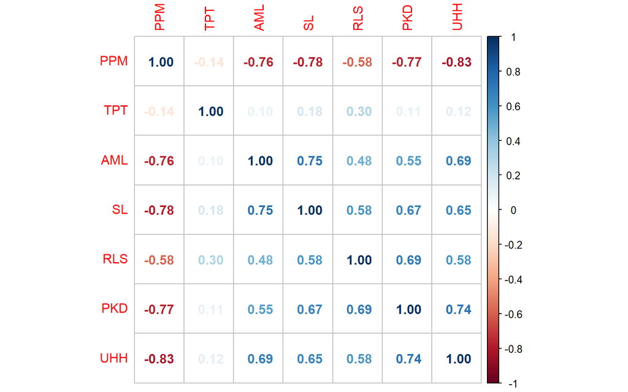

```r
corrplot(cor(data[,2:8]), method = "number")
```

## Sebaran Spasial Data

### Sebaran Spasial PPM

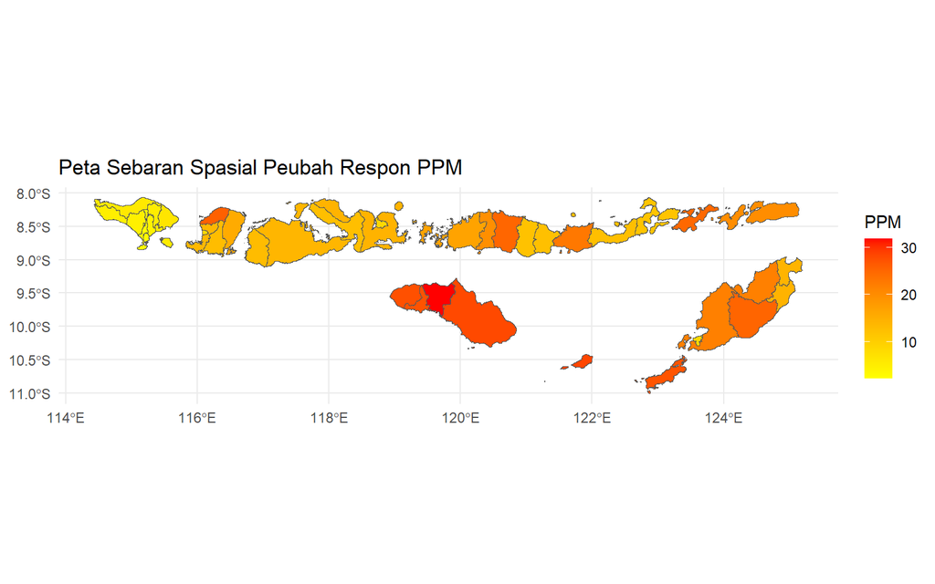

```r
ggplot(merged_map) +
  geom_sf(aes(fill = PPM)) +
  scale_fill_gradient(low = "yellow", high = "red") +
  labs(title = "Peta Sebaran Spasial Peubah Respon PPM") +
  theme_minimal()
```

### Sebaran Spasial TPT

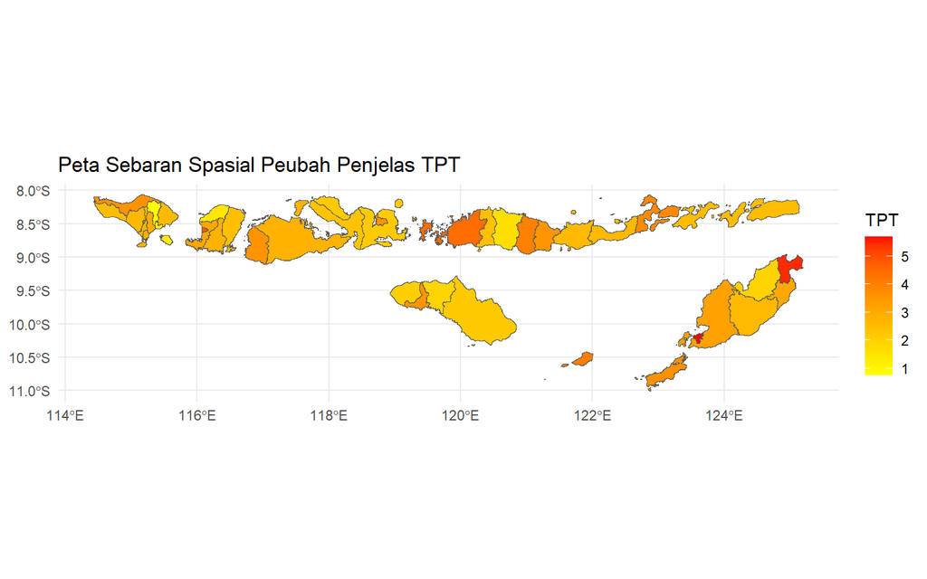

```r
ggplot(merged_map) +
  geom_sf(aes(fill = TPT)) +
  scale_fill_gradient(low = "yellow", high = "red") +
  labs(title = "Peta Sebaran Spasial Peubah Penjelas TPT") +
  theme_minimal()
```

### Sebaran Spasial AML

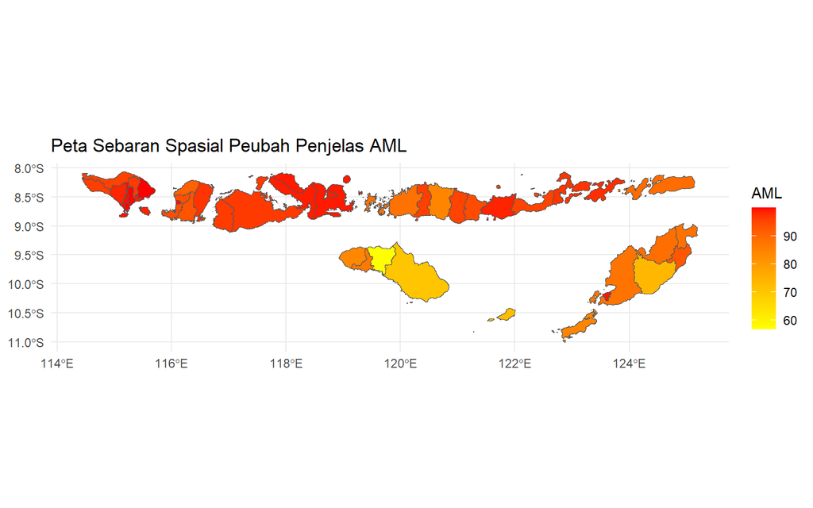

```r
ggplot(merged_map) +
  geom_sf(aes(fill = AML)) +
  scale_fill_gradient(low = "yellow", high = "red") +
  labs(title = "Peta Sebaran Spasial Peubah Penjelas AML") +
  theme_minimal()
```

### Sebaran Spasial SL

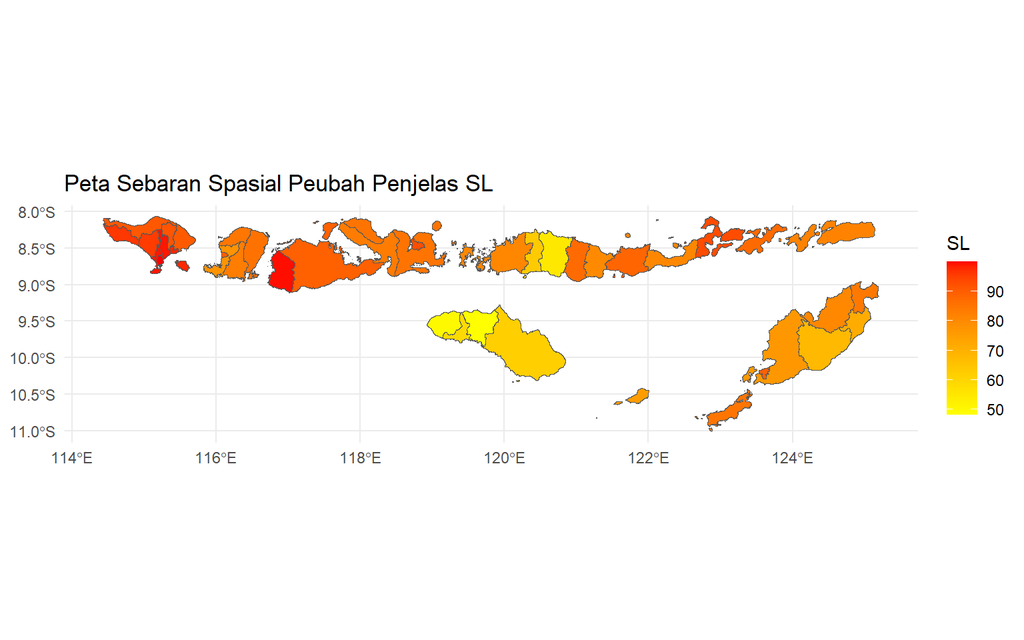

```r
ggplot(merged_map) +
  geom_sf(aes(fill = SL)) +
  scale_fill_gradient(low = "yellow", high = "red") +
  labs(title = "Peta Sebaran Spasial Peubah Penjelas SL") +
  theme_minimal()
```

### Sebaran Spasial RLS

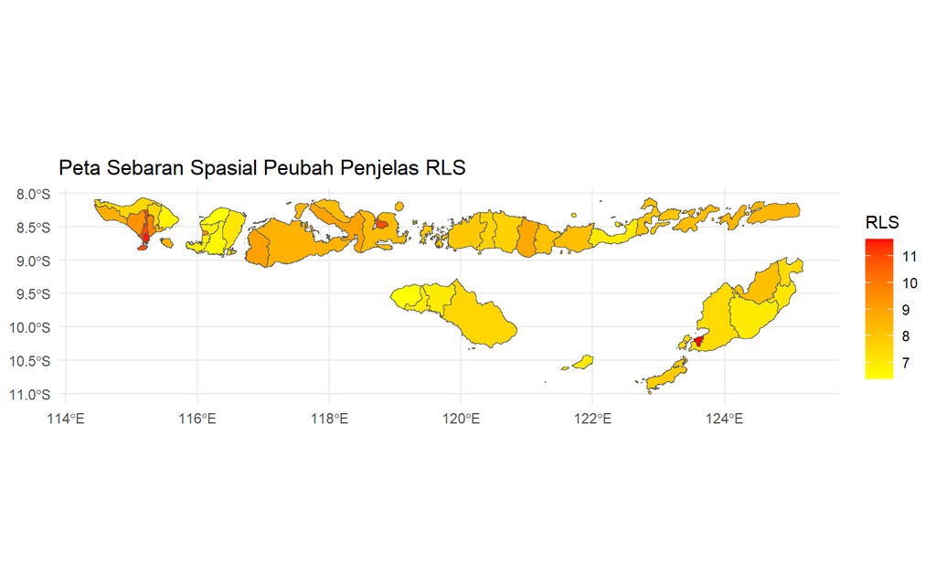

```r
ggplot(merged_map) +
  geom_sf(aes(fill = RLS)) +
  scale_fill_gradient(low = "yellow", high = "red") +
  labs(title = "Peta Sebaran Spasial Peubah Penjelas RLS") +
  theme_minimal()
```

### Sebaran Spasial PKD

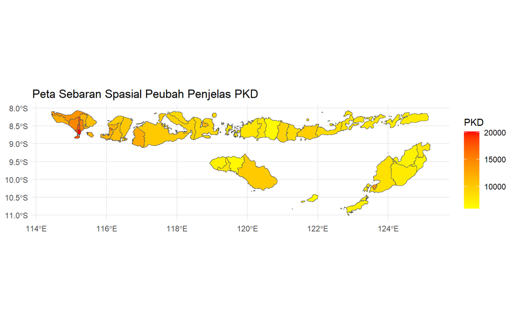

```r
ggplot(merged_map) +
  geom_sf(aes(fill = PKD)) +
  scale_fill_gradient(low = "yellow", high = "red") +
  labs(title = "Peta Sebaran Spasial Peubah Penjelas PKD") +
  theme_minimal()
```

### Sebaran Spasial UHH

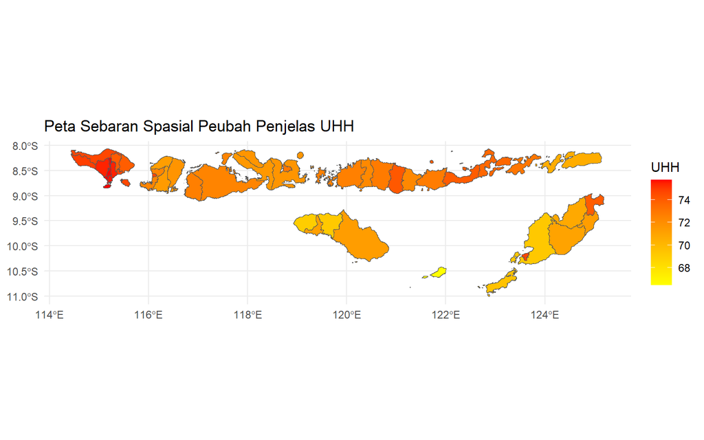

```r
ggplot(merged_map) +
  geom_sf(aes(fill = UHH)) +
  scale_fill_gradient(low = "yellow", high = "red") +
  labs(title = "Peta Sebaran Spasial Peubah Penjelas UHH") +
  theme_minimal()
```

# Matriks Pembobot Spasial (Berdasarkan Jarak)

```r
koord <- st_coordinates(st_centroid(st_geometry(merged_map)))
koord
```

```
##              X          Y
##  [1,] 124.5688  -8.303784
##  [2,] 115.1884  -8.583385
##  [3,] 115.3468  -8.293573
##  [4,] 124.9685  -9.153833
##  [5,] 118.6184  -8.474820
##  [6,] 114.9626  -8.200296
##  [7,] 118.2167  -8.472147
##  [8,] 121.7342  -8.677239
##  [9,] 122.9445  -8.365089
## [10,] 115.2876  -8.480476
## [11,] 114.6826  -8.312530
## [12,] 115.5301  -8.374190
## [13,] 115.4935  -8.666528
## [14,] 118.7849  -8.455799
```

[output cut: 27 more lines]

```r
jarak<-dist(koord, method = "euclidean")
m.jarak<-as.matrix(jarak)
```

## KNN

```r
W.knn<-knn2nb(knearneigh(koord,k=5,longlat=TRUE))
W.knn.s <- nb2listw(W.knn,style='W')

MI.knn <- moran(data$PPM,W.knn.s,n=length(W.knn.s$neighbours),S0=Szero(W.knn.s))
mt1 = moran.test(data$PPM,W.knn.s,randomisation = T,alternative = "greater")
mt1
```

```
##
##  Moran I test under randomisation
##
## data:  data$PPM
## weights: W.knn.s
##
## Moran I statistic standard deviate = 3.9509, p-value = 3.893e-05
## alternative hypothesis: greater
## sample estimates:
## Moran I statistic       Expectation          Variance
##       0.321663699      -0.025000000       0.007698808
```

## RDW

```r
W.rdw <-dnearneigh(koord,0,160,longlat=TRUE)
W.rdw.s <- nb2listw(W.rdw,style='W')

MI.rdw <- moran(data$PPM,W.rdw.s,n=length(W.rdw.s$neighbours),S0=Szero(W.rdw.s))
mt2 = moran.test(data$PPM,W.rdw.s,randomisation = T,alternative = "greater")
mt2
```

```
##
##  Moran I test under randomisation
##
## data:  data$PPM
## weights: W.rdw.s
##
## Moran I statistic standard deviate = 1.8404, p-value = 0.03286
## alternative hypothesis: greater
## sample estimates:
## Moran I statistic       Expectation          Variance
##       0.124062148      -0.025000000       0.006560452
```

## IDW

```r
alpha1=1
W.idw <-1/(m.jarak^alpha1)
diag(W.idw)<-0
rtot<-rowSums(W.idw,na.rm=TRUE)
W.idw.sd<-W.idw/rtot
W.idw.s = mat2listw(W.idw.sd,style='W')

MI.idw <- moran(data$PPM,W.idw.s,n=length(W.idw.s$neighbours),S0=Szero(W.idw.s))
mt3 = moran.test(data$PPM,W.idw.s,randomisation = T,alternative = "greater")
mt3
```

```
##
##  Moran I test under randomisation
##
## data:  data$PPM
## weights: W.idw.s
##
## Moran I statistic standard deviate = 3.1212, p-value = 0.0009006
## alternative hypothesis: greater
## sample estimates:
## Moran I statistic       Expectation          Variance
##       0.118526511      -0.025000000       0.002114563
```

```r
alpha2=2
W.idw2<-1/(m.jarak^alpha2)
diag(W.idw2)<-0
rtot<-rowSums(W.idw2,na.rm=TRUE)
W.idw2.sd<-W.idw2/rtot
W.idw2.s = mat2listw(W.idw2.sd,style='W')

MI.idw2 <- moran(data$PPM,W.idw2.s,n=length(W.idw2.s$neighbours),S0=Szero(W.idw2.s))
mt4 = moran.test(data$PPM,W.idw2.s,randomisation = T,alternative = "greater")
mt4
```

```
##
##  Moran I test under randomisation
##
## data:  data$PPM
## weights: W.idw2.s
##
## Moran I statistic standard deviate = 3.0741, p-value = 0.001056
## alternative hypothesis: greater
## sample estimates:
## Moran I statistic       Expectation          Variance
##        0.28412266       -0.02500000        0.01011206
```

## EDW

```r
alpha=1
W.edw<-exp((-alpha)*m.jarak)
diag(W.edw)<-0
rtot<-rowSums(W.edw,na.rm=TRUE)
W.edw.sd<-W.edw/rtot
W.edw.s = mat2listw(W.edw.sd,style='W')

MI.edw <- moran(data$PPM,W.edw.s,n=length(W.edw.s$neighbours),S0=Szero(W.edw.s))
mt5 = moran.test(data$PPM,W.edw.s,randomisation = T,alternative = "greater")
mt5
```

```
##
##  Moran I test under randomisation
##
## data:  data$PPM
## weights: W.edw.s
##
## Moran I statistic standard deviate = 2.6666, p-value = 0.003831
## alternative hypothesis: greater
## sample estimates:
## Moran I statistic       Expectation          Variance
##       0.118067814      -0.025000000       0.002878529
```

```r
alpha2=2
W.edw2<-exp((-alpha2)*m.jarak)
diag(W.edw2)<-0
rtot<-rowSums(W.edw2,na.rm=TRUE)
W.edw2.sd<-W.edw2/rtot
W.edw2.s = mat2listw(W.edw2.sd,style='W')
MI.edw2 <- moran(data$PPM,W.edw2.s,n=length(W.edw2.s$neighbours),S0=Szero(W.edw2.s))
mt6 = moran.test(data$PPM,W.edw2.s,randomisation = T,alternative = "greater")
mt6
```

```
##
##  Moran I test under randomisation
##
## data:  data$PPM
## weights: W.edw2.s
##
## Moran I statistic standard deviate = 3.2942, p-value = 0.0004934
## alternative hypothesis: greater
## sample estimates:
## Moran I statistic       Expectation          Variance
##       0.244019387      -0.025000000       0.006668907
```

## Pemilihan Matriks Pembobot Terbaik

```r
MatriksBobot <- c("K-Nearest Neighbor (k=5)",
                  "Radial Distance Weight (dmax=160)",
                  "Invers Distance Weight (alpha=1)",
                  "Invers Distance Weight (alpha=2)",
                  "Exponential Distance Weight (alpha=1)",
                  "Exponential Distance Weight (alpha=2)")
IndeksMoran <- c(MI.knn$I,MI.rdw$I,MI.idw$I,MI.idw2$I,MI.edw$I,MI.edw2$I)
pv = c(mt1$p.value,mt2$p.value,mt3$p.value,mt4$p.value,mt5$p.value,mt6$p.value)
Matriks = cbind.data.frame(MatriksBobot, IndeksMoran,"p-value"=pv)
colnames(Matriks) <-c("Matriks Bobot", "Indeks Moran", "p-value")
Matriks
```

```
##                           Matriks Bobot Indeks Moran      p-value
## 1              K-Nearest Neighbor (k=5)    0.3216637 3.892806e-05
## 2     Radial Distance Weight (dmax=160)    0.1240621 3.285841e-02
## 3      Invers Distance Weight (alpha=1)    0.1185265 9.005740e-04
## 4      Invers Distance Weight (alpha=2)    0.2841227 1.055869e-03
## 5 Exponential Distance Weight (alpha=1)    0.1180678 3.831228e-03
## 6 Exponential Distance Weight (alpha=2)    0.2440194 4.934276e-04
```

```r
Matriks[Matriks$`p-value`< 0.05,]
```

```
##                           Matriks Bobot Indeks Moran      p-value
## 1              K-Nearest Neighbor (k=5)    0.3216637 3.892806e-05
## 2     Radial Distance Weight (dmax=160)    0.1240621 3.285841e-02
## 3      Invers Distance Weight (alpha=1)    0.1185265 9.005740e-04
## 4      Invers Distance Weight (alpha=2)    0.2841227 1.055869e-03
## 5 Exponential Distance Weight (alpha=1)    0.1180678 3.831228e-03
## 6 Exponential Distance Weight (alpha=2)    0.2440194 4.934276e-04
```

Dipilih matriks pembobot KNN dan IDW dengan alpha=2 karena memiliki indeks moran terbesar dan nilai p kurang dari alpha sebagai perbandingan

# Model Regresi MKT/OLS

## Pemodelan

```r
ols <- lm(PPM~TPT+AML+SL+RLS+PKD+UHH, data=data)
summary(ols)
```

```
##
## Call:
## lm(formula = PPM ~ TPT + AML + SL + RLS + PKD + UHH, data = data)
##
## Residuals:
##     Min      1Q  Median      3Q     Max
## -6.4023 -2.6165 -0.5318  0.7878 10.2359
##
## Coefficients:
##               Estimate Std. Error t value Pr(>|t|)
## (Intercept)  1.557e+02  3.177e+01   4.901 2.31e-05 ***
## TPT         -2.215e-01  6.349e-01  -0.349  0.72934
## AML         -1.902e-01  1.075e-01  -1.768  0.08599 .
## SL          -1.504e-01  7.851e-02  -1.916  0.06386 .
## RLS          4.016e-01  6.847e-01   0.587  0.56139
## PKD         -6.807e-04  3.350e-04  -2.032  0.05001 .
## UHH         -1.463e+00  5.114e-01  -2.861  0.00717 **
## ---
## Signif. codes:  0 '***' 0.001 '**' 0.01 '*' 0.05 '.' 0.1 ' ' 1
##
## Residual standard error: 3.879 on 34 degrees of freedom
## Multiple R-squared:  0.8194, Adjusted R-squared:  0.7876
## F-statistic: 25.72 on 6 and 34 DF,  p-value: 2.71e-11
```

```r
print(paste("Nilai AIC OLS", AIC(ols)))
```

```
## [1] "Nilai AIC OLS 235.826294241679"
```

## Model Diagnostik

### Uji Normalitas Sisaan

```r
err.ols <- residuals(ols)
ad.test(err.ols)
```

```
##
##  Anderson-Darling normality test
##
## data:  err.ols
## A = 1.4297, p-value = 0.0009218
```

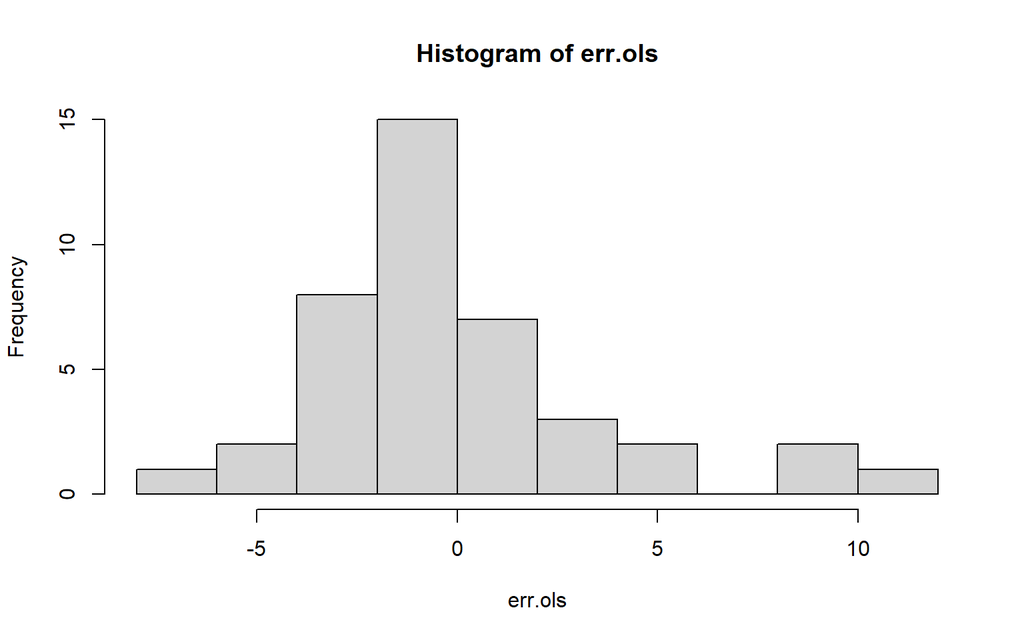

```r
hist(err.ols)
```

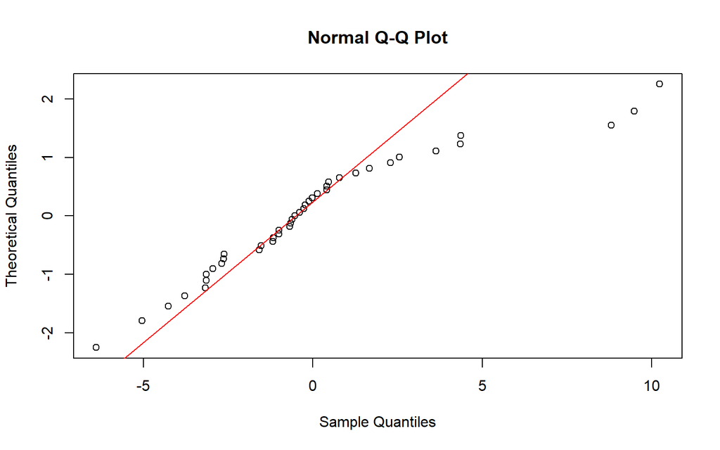

```r
qqnorm(err.ols,datax=T)
qqline(rnorm(length(err.ols),mean(err.ols),sd(err.ols)),datax=T, col="red")
```

### Uji Kehomogenan Ragam

```r
lmtest::bptest(ols)
```

```
##
##  studentized Breusch-Pagan test
##
## data:  ols
## BP = 5.6832, df = 6, p-value = 0.4596
```

### Uji Multikolinearitas

```r
car::vif(ols)
```

```
##      TPT      AML       SL      RLS      PKD      UHH
## 1.141199 2.752197 2.975242 2.231573 3.199191 2.988148
```

# KNN

## Pengujian Efek Spasial

### Efek Dependensi Spasial

#### Uji Indeks Moran

##### Uji Indeks Moran pada Galat Regresi

```r
ww = W.knn.s
lm.morantest(ols, listw=ww, alternative="two.sided", zero.policy = TRUE)
```

```
##
##  Global Moran I for regression residuals
##
## data:
## model: lm(formula = PPM ~ TPT + AML + SL + RLS + PKD + UHH, data =
## data)
## weights: ww
##
## Moran I statistic standard deviate = 1.5337, p-value = 0.1251
## alternative hypothesis: two.sided
## sample estimates:
## Observed Moran I      Expectation         Variance
##      0.094926148     -0.033097160      0.006968237
```

```r
err.ols <- residuals(ols)
merr <- moran.test(err.ols, ww,randomisation=T,
           alternative="two.sided")
merr
```

```
##
##  Moran I test under randomisation
##
## data:  err.ols
## weights: ww
##
## Moran I statistic standard deviate = 1.4202, p-value = 0.1555
## alternative hypothesis: two.sided
## sample estimates:
## Moran I statistic       Expectation          Variance
##       0.094926148      -0.025000000       0.007130481
```

#### Uji Lagrange Multiplier

```r
model <- lm.LMtests(ols,listw=ww,zero.policy = TRUE, test=c("LMerr","RLMerr","LMlag","RLMlag","SARMA"))
```

```
## Please update scripts to use lm.RStests in place of lm.LMtests
```

```r
summary(model)
```

```
##  Rao's score (a.k.a Lagrange multiplier) diagnostics for spatial
##  dependence
## data:
## model: lm(formula = PPM ~ TPT + AML + SL + RLS + PKD + UHH, data =
## data)
## test weights: listw
##
##          statistic parameter p.value
## RSerr     1.026250         1 0.31104
## RSlag     3.621476         1 0.05704 .
## adjRSerr  0.001874         1 0.96547
## adjRSlag  2.597101         1 0.10706
## SARMA     3.623350         2 0.16338
## ---
## Signif. codes:  0 '***' 0.001 '**' 0.01 '*' 0.05 '.' 0.1 ' ' 1
```

Output menunjukkan bahwa tidak ada hasil uji LM yang signifikan pada taraf 5%

# IDW.2

## Pengujian Efek Spasial

### Efek Dependensi Spasial

#### Uji Indeks Moran

##### Uji Indeks Moran pada Galat Regresi

```r
ww = W.idw2.s
lm.morantest(ols, listw=ww, alternative="two.sided", zero.policy = TRUE)
```

```
##
##  Global Moran I for regression residuals
##
## data:
## model: lm(formula = PPM ~ TPT + AML + SL + RLS + PKD + UHH, data =
## data)
## weights: ww
##
## Moran I statistic standard deviate = 2.209, p-value = 0.02717
## alternative hypothesis: two.sided
## sample estimates:
## Observed Moran I      Expectation         Variance
##      0.183170106     -0.030467639      0.009353332
```

```r
err.ols <- residuals(ols)
merr <- moran.test(err.ols, ww,randomisation=T,
           alternative="two.sided")
merr
```

```
##
##  Moran I test under randomisation
##
## data:  err.ols
## weights: ww
##
## Moran I statistic standard deviate = 2.1511, p-value = 0.03147
## alternative hypothesis: two.sided
## sample estimates:
## Moran I statistic       Expectation          Variance
##       0.183170106      -0.025000000       0.009364923
```

##### Uji Indeks Moran pada Peubah Y

```r
my <- moran.test(data$PPM, ww,randomisation=T,
           alternative="two.sided")
my
```

```
##
##  Moran I test under randomisation
##
## data:  data$PPM
## weights: ww
##
## Moran I statistic standard deviate = 3.0741, p-value = 0.002112
## alternative hypothesis: two.sided
## sample estimates:
## Moran I statistic       Expectation          Variance
##        0.28412266       -0.02500000        0.01011206
```

##### Uji Indeks Moran pada Peubah TPT

```r
mx1 <- moran.test(data$TPT, ww,randomisation=T,
           alternative="two.sided")
mx1
```

```
##
##  Moran I test under randomisation
##
## data:  data$TPT
## weights: ww
##
## Moran I statistic standard deviate = -0.18502, p-value = 0.8532
## alternative hypothesis: two.sided
## sample estimates:
## Moran I statistic       Expectation          Variance
##      -0.043160808      -0.025000000       0.009634932
```

##### Uji Indeks Moran pada Peubah AML

```r
mx2 <- moran.test(data$AML, ww,randomisation=T,
           alternative="two.sided")
mx2
```

```
##
##  Moran I test under randomisation
##
## data:  data$AML
## weights: ww
##
## Moran I statistic standard deviate = 2.9517, p-value = 0.00316
## alternative hypothesis: two.sided
## sample estimates:
## Moran I statistic       Expectation          Variance
##       0.252218703      -0.025000000       0.008820591
```

##### Uji Indeks Moran pada Peubah SL

```r
mx3 <- moran.test(data$SL, ww,randomisation=T,
           alternative="two.sided")
mx3
```

```
##
##  Moran I test under randomisation
##
## data:  data$SL
## weights: ww
##
## Moran I statistic standard deviate = 1.6031, p-value = 0.1089
## alternative hypothesis: two.sided
## sample estimates:
## Moran I statistic       Expectation          Variance
##       0.133064413      -0.025000000       0.009721368
```

##### Uji Indeks Moran pada Peubah RLS

```r
mx4 <- moran.test(data$RLS, ww,randomisation=T,
           alternative="two.sided")
mx4
```

```
##
##  Moran I test under randomisation
##
## data:  data$RLS
## weights: ww
##
## Moran I statistic standard deviate = 2.3301, p-value = 0.0198
## alternative hypothesis: two.sided
## sample estimates:
## Moran I statistic       Expectation          Variance
##       0.203773150      -0.025000000       0.009639684
```

##### Uji Indeks Moran pada Peubah PKD

```r
mx5 <- moran.test(data$PKD, ww,randomisation=T,
           alternative="two.sided")
mx5
```

```
##
##  Moran I test under randomisation
##
## data:  data$PKD
## weights: ww
##
## Moran I statistic standard deviate = 1.0623, p-value = 0.2881
## alternative hypothesis: two.sided
## sample estimates:
## Moran I statistic       Expectation          Variance
##       0.078884774      -0.025000000       0.009563084
```

##### Uji Indeks Moran pada Peubah UHH

```r
mx6 <- moran.test(data$UHH, ww,randomisation=T,
           alternative="two.sided")
mx6
```

```
##
##  Moran I test under randomisation
##
## data:  data$UHH
## weights: ww
##
## Moran I statistic standard deviate = 0.64494, p-value = 0.519
## alternative hypothesis: two.sided
## sample estimates:
## Moran I statistic       Expectation          Variance
##       0.038673503      -0.025000000       0.009747203
```

```r
Peubah = c("PPM", "TPT", "AML", "SL", "RLS", "PKD", "UHH", "Sisaan")
Indeks_Moran = c(my$estimate[1], mx1$estimate[1], mx2$estimate[1], mx3$estimate[1], mx4$estimate[1], mx5$estimate[1], mx6$estimate[1], merr$estimate[1])
p_value = c(my$p.value, mx1$p.value, mx2$p.value, mx3$p.value, mx4$p.value, mx5$p.value, mx6$p.value, merr$p.value)

df1 = cbind.data.frame(Peubah, Indeks_Moran, p_value)
colnames(df1) <- c("Peubah", "Indeks Moran", "p-value")
df1
```

```
##   Peubah Indeks Moran     p-value
## 1    PPM   0.28412266 0.002111738
## 2    TPT  -0.04316081 0.853215968
## 3    AML   0.25221870 0.003160195
## 4     SL   0.13306441 0.108904594
## 5    RLS   0.20377315 0.019801124
## 6    PKD   0.07888477 0.288093153
## 7    UHH   0.03867350 0.518966626
## 8 Sisaan   0.18317011 0.031466100
```

Berdasarkan hasil pengujian Indeks Moran di atas menunjukkan bahwa nilai indeks Moran pada peubah PPM, AML, RLS, dan sisaan model regresimemiliki nilai p-value < 0.05 maka Tolak H0 sehingga autokorelasi spasial pada peubah tersebut berpengaruh nyata. Hal ini mengindikasikan bahwa terdapat ketergantungan spasial pada peubah PPM dan sisaan model regresi klasik. Terlihat pula nilai indeks moran positif pada peubah PPM, AML, RLS, dan sisaan model regresi klasik menunjukkan adanya autokorelasi positif.

Sedangkan, nilai indeks moran pada peubah TPT, SL, PKD, UHH memiliki p-value > 0.05 maka gagal tolak H0 artinya tidak terdapat autokorelasi spasial peubah TPT, SL, PKD, UHH taraf nyata 5%.

Oleh karenanya, untuk mencari model yang lebih baik, kita dapat melakukan uji LM (lagrange multiplier) untuk mengidentifikasi model dependensi spasial yang dapat digunakan pada kasus ini.

#### Uji Lagrange Multiplier

```r
model <- lm.LMtests(ols,listw=ww,zero.policy = TRUE, test=c("LMerr","RLMerr","LMlag","RLMlag","SARMA"))
```

```
## Please update scripts to use lm.RStests in place of lm.LMtests
```

```r
summary(model)
```

```
##  Rao's score (a.k.a Lagrange multiplier) diagnostics for spatial
##  dependence
## data:
## model: lm(formula = PPM ~ TPT + AML + SL + RLS + PKD + UHH, data =
## data)
## test weights: listw
##
##          statistic parameter p.value
## RSerr      3.01130         1 0.08269 .
## RSlag      5.86925         1 0.01541 *
## adjRSerr   0.13801         1 0.71027
## adjRSlag   2.99597         1 0.08347 .
## SARMA      6.00726         2 0.04961 *
## ---
## Signif. codes:  0 '***' 0.001 '**' 0.01 '*' 0.05 '.' 0.1 ' ' 1
```

Output menunjukkan bahwa hasil uji LM model SAR dan GSM signifikan pada taraf 5%. Berdasarkan skema tersebut, maka kita dapat mencoba kandidat model SAR dan SARMA.

### Efek Heterogenitas Spasial

```r
lmtest::bptest(ols)
```

```
##
##  studentized Breusch-Pagan test
##
## data:  ols
## BP = 5.6832, df = 6, p-value = 0.4596
```

Tidak terdapat efek heterogenitas spasial

## Model Regresi Spasial

### Model SAR

```r
sar <- lagsarlm(ols, data = data, listw = ww)
(sum <- summary(sar, Nagelkerke = T))
```

```
##
## Call:lagsarlm(formula = ols, data = data, listw = ww)
##
## Residuals:
##      Min       1Q   Median       3Q      Max
## -5.62295 -1.95289 -0.42954  1.51314  9.96829
##
## Type: lag
## Coefficients: (asymptotic standard errors)
##                Estimate  Std. Error z value  Pr(>|z|)
## (Intercept)  1.6026e+02  2.6666e+01  6.0098 1.858e-09
## TPT         -4.3674e-01  5.3293e-01 -0.8195   0.41250
## AML         -9.1141e-02  9.6544e-02 -0.9440   0.34515
## SL          -1.3259e-01  6.5948e-02 -2.0105   0.04437
## RLS          7.2756e-01  5.8244e-01  1.2492   0.21161
## PKD         -7.1359e-04  2.8151e-04 -2.5349   0.01125
## UHH         -1.7603e+00  4.3609e-01 -4.0366 5.424e-05
##
## Rho: 0.3038, LR test value: 5.8002, p-value: 0.016025
## Asymptotic standard error: 0.11856
##     z-value: 2.5624, p-value: 0.010395
## Wald statistic: 6.5659, p-value: 0.010395
##
## Log likelihood: -107.0131 for lag model
## ML residual variance (sigma squared): 10.594, (sigma: 3.2549)
## Nagelkerke pseudo-R-squared: 0.84327
## Number of observations: 41
## Number of parameters estimated: 9
## AIC: 232.03, (AIC for lm: 235.83)
## LM test for residual autocorrelation
## test value: 0.56107, p-value: 0.45383
```

```r
err.sar<-residuals(sar)
ad.test(err.sar)
```

```
##
##  Anderson-Darling normality test
##
## data:  err.sar
## A = 0.92718, p-value = 0.01679
```

```r
bptest.Sarlm(sar)
```

```
##
##  studentized Breusch-Pagan test
##
## data:
## BP = 5.4784, df = 6, p-value = 0.4841
```

```r
moran.test(err.sar, ww, alternative="two.sided")
```

```
##
##  Moran I test under randomisation
##
## data:  err.sar
## weights: ww
##
## Moran I statistic standard deviate = 0.9199, p-value = 0.3576
## alternative hypothesis: two.sided
## sample estimates:
## Moran I statistic       Expectation          Variance
##       0.063630340      -0.025000000       0.009282901
```

### Model GSM/SARMA

```r
SARMA <- sacsarlm(ols,data=data,ww, zero.policy = TRUE)
summary(SARMA)
```

```
##
## Call:sacsarlm(formula = ols, data = data, listw = ww, zero.policy = TRUE)
##
## Residuals:
##      Min       1Q   Median       3Q      Max
## -5.73214 -1.57802 -0.51778  1.39102  9.92166
##
## Type: sac
## Coefficients: (asymptotic standard errors)
##                Estimate  Std. Error z value  Pr(>|z|)
## (Intercept)  1.6899e+02  2.6122e+01  6.4693 9.843e-11
## TPT         -7.5856e-01  4.9801e-01 -1.5232   0.12772
## AML         -1.0663e-01  9.2141e-02 -1.1572   0.24719
## SL          -1.1987e-01  6.1717e-02 -1.9423   0.05210
## RLS          8.4528e-01  5.7788e-01  1.4627   0.14354
## PKD         -6.7533e-04  2.9050e-04 -2.3247   0.02009
## UHH         -1.8631e+00  4.2431e-01 -4.3908 1.129e-05
##
## Rho: 0.2083
## Asymptotic standard error: 0.17347
##     z-value: 1.2008, p-value: 0.22984
## Lambda: 0.34842
## Asymptotic standard error: 0.2457
##     z-value: 1.4181, p-value: 0.15617
##
## LR test value: 6.7933, p-value: 0.033486
##
## Log likelihood: -106.5165 for sac model
## ML residual variance (sigma squared): 10.162, (sigma: 3.1878)
## Number of observations: 41
## Number of parameters estimated: 10
## AIC: 233.03, (AIC for lm: 235.83)
```

```r
err.SARMA<-residuals(SARMA)
ad.test(err.SARMA)
```

```
##
##  Anderson-Darling normality test
##
## data:  err.SARMA
## A = 0.87184, p-value = 0.02313
```

```r
bptest.Sarlm(SARMA)
```

```
##
##  studentized Breusch-Pagan test
##
## data:
## BP = 6.4075, df = 6, p-value = 0.3791
```

```r
moran.test(err.SARMA, ww, alternative="two.sided")
```

```
##
##  Moran I test under randomisation
##
## data:  err.SARMA
## weights: ww
##
## Moran I statistic standard deviate = 0.40311, p-value = 0.6869
## alternative hypothesis: two.sided
## sample estimates:
## Moran I statistic       Expectation          Variance
##       0.013847281      -0.025000000       0.009286865
```

## Goodness of Fits

```r
df <- data.frame("Model" = c("OLS (Regresi KlasiK)","SAR","SARMA"),
           "AIC" = c(AIC(ols), AIC(sar), AIC(SARMA)))

df
```

```
##                  Model      AIC
## 1 OLS (Regresi KlasiK) 235.8263
## 2                  SAR 232.0261
## 3                SARMA 233.0330
```

Dipilih model SAR dengan AIC terkecil

Dipilih model SAR dengan matriks pembobot IDW alpha=2

# Efek Marginal

## *Spill Over*

```r
Im <- impacts(sar, listw = W.idw2.s)
Im
```

```
## Impact measures (lag, exact):
##            Direct      Indirect       Total
## TPT -0.4468763805 -0.1804410932 -0.62731747
## AML -0.0932572165 -0.0376556802 -0.13091290
## SL  -0.1356698363 -0.0547811758 -0.19045101
## RLS  0.7444552647  0.3005983929  1.04505366
## PKD -0.0007301625 -0.0002948272 -0.00102499
## UHH -1.8011583490 -0.7272771525 -2.52843550
```

## Umpan Balik

```r
koef = sum$coefficients[-1]
diref = Im$direct
umbal = diref-koef
cbind.data.frame(Koefisien=koef,EfekLangsung=diref,UmpanBalik=umbal)
```

```
##         Koefisien  EfekLangsung    UmpanBalik
## TPT -0.4367359810 -0.4468763805 -1.014040e-02
## AML -0.0911410486 -0.0932572165 -2.116168e-03
## SL  -0.1325912526 -0.1356698363 -3.078584e-03
## RLS  0.7275622845  0.7444552647  1.689298e-02
## PKD -0.0007135938 -0.0007301625 -1.656865e-05
## UHH -1.7602869445 -1.8011583490 -4.087140e-02
```

# Kesimpulan Model

```r
sar <- lagsarlm(ols, data = data, listw = W.idw2.s)
summary(sar, Nagelkerke = T)
```

```
##
## Call:lagsarlm(formula = ols, data = data, listw = W.idw2.s)
##
## Residuals:
##      Min       1Q   Median       3Q      Max
## -5.62295 -1.95289 -0.42954  1.51314  9.96829
##
## Type: lag
## Coefficients: (asymptotic standard errors)
##                Estimate  Std. Error z value  Pr(>|z|)
## (Intercept)  1.6026e+02  2.6666e+01  6.0098 1.858e-09
## TPT         -4.3674e-01  5.3293e-01 -0.8195   0.41250
## AML         -9.1141e-02  9.6544e-02 -0.9440   0.34515
## SL          -1.3259e-01  6.5948e-02 -2.0105   0.04437
## RLS          7.2756e-01  5.8244e-01  1.2492   0.21161
## PKD         -7.1359e-04  2.8151e-04 -2.5349   0.01125
## UHH         -1.7603e+00  4.3609e-01 -4.0366 5.424e-05
##
## Rho: 0.3038, LR test value: 5.8002, p-value: 0.016025
## Asymptotic standard error: 0.11856
##     z-value: 2.5624, p-value: 0.010395
## Wald statistic: 6.5659, p-value: 0.010395
##
## Log likelihood: -107.0131 for lag model
## ML residual variance (sigma squared): 10.594, (sigma: 3.2549)
## Nagelkerke pseudo-R-squared: 0.84327
## Number of observations: 41
## Number of parameters estimated: 9
## AIC: 232.03, (AIC for lm: 235.83)
## LM test for residual autocorrelation
## test value: 0.56107, p-value: 0.45383
```

Diperoleh persamaan sebagai berikut

$$\hat{PPM} = 0.3038 W y + 160.26 - 0.4367 \text{TPT} - 0.0911 \text{AML}
- 0.1326 \text{SL} + 0.7276 \text{RLS} - 0.0007136 \text{PKD} - 1.7603
\text{UHH}$$